# 01_FirstAnalysis

Nick Diercksen

# Overview

## Preparing data

```r
gastroc <-
  readr::read_tsv("./data/counts/readcount_genename_gastroc.xls",
                  show_col_types = F) %>%
  tibble::column_to_rownames(var = "gene_id")
counts.gastroc <- gastroc[, 1:12]

# TODO: fix annotations: several entries are incomplete whereas the gastroc seems to be complete
soleus <- readr::read_tsv("./data/counts/readcount_genename_soleus.xls", show_col_types = F) %>%
  tibble::column_to_rownames(var = "gene_id")
counts.soleus <- soleus[, 1:12]
```

## Treemap

Both counts have the same genes analysed. These amount to nearly 54,000 genes, which corresponds to the whole genome of mice.

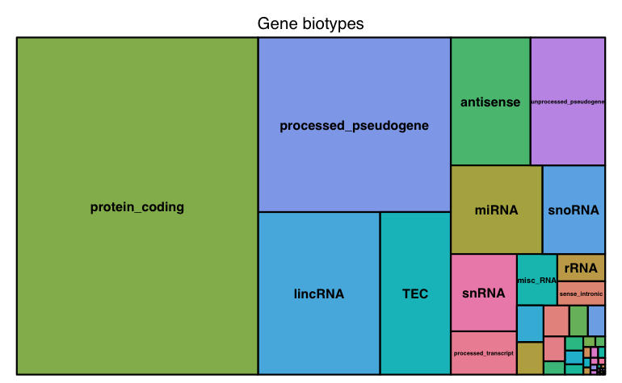

```r
gene_biotypes <- table(gastroc$gene_biotype) %>%
  as.data.frame() %>%
  arrange(desc(Freq))

treemap::treemap(gene_biotypes,
                 index = "Var1",
                 vSize = "Freq",
                 title = "Gene biotypes")
```

# Filtering

## Overview

For a broad overview all genes with `rowSums() < 10` will be displayed. This is usually similar to omitting genes with zero counts of more than 30%

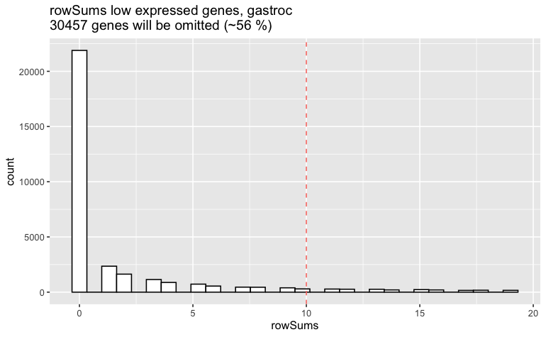

```r
rs.gastroc <- rowSums(counts.gastroc) %>%
  as.data.frame() %>%
  dplyr::rename("rowSums" = ".")
n.omit.gastroc <- sum(rs.gastroc < 10)
title <- paste0("rowSums low expressed genes, gastroc \n",
                n.omit.gastroc, " genes will be omitted (~",
                floor(n.omit.gastroc / nrow(rs.gastroc) * 100), " %)")

p.gastroc <- filter(rs.gastroc, rowSums < 20) %>%
  ggplot(., aes(x=rowSums))+
  geom_histogram(color="black", fill="white")+
  geom_vline(aes(xintercept=10, color="red"),
             linetype="dashed") +
  ggtitle(title) +
  theme(legend.position = "none")

# ---
rs.soleus <- rowSums(counts.soleus) %>%
  as.data.frame() %>%
  dplyr::rename("rowSums" = ".")
n.omit.soleus <- sum(rs.soleus < 10)
title <- paste0("rowSums low expressed genes, soleus \n",
                n.omit.soleus, " genes will be omitted (~",
                floor(n.omit.gastroc / nrow(rs.gastroc) * 100), " %)")

p.soleus <- filter(rs.soleus, rowSums < 20) %>%
  ggplot(., aes(x=rowSums))+
  geom_histogram(color="black", fill="white")+
  geom_vline(aes(xintercept=10, color="red"),
             linetype="dashed") +
  ggtitle(title)+
  theme(legend.position = "none")

p.gastroc
```

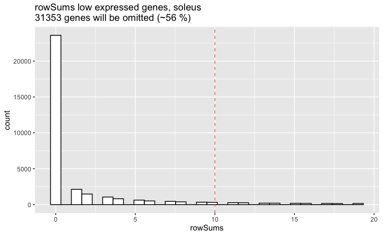

```r
p.soleus
```

## omitting genes (actual filtering)

# Quality assessment

## Library sizes

- too many zero counts
- different total counts

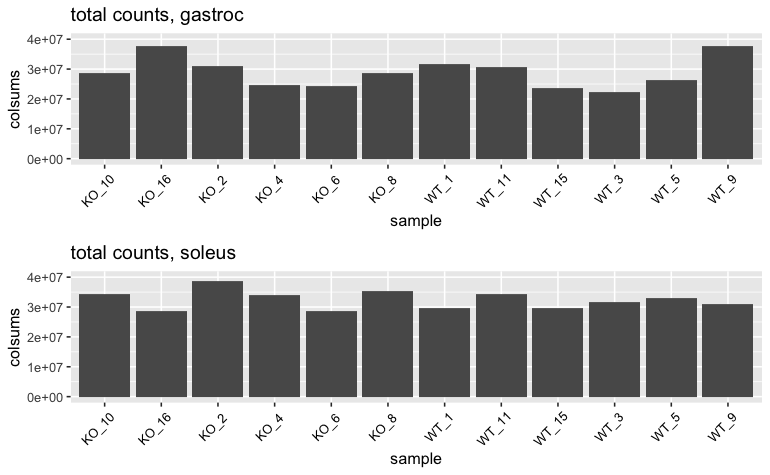

```r
plot.library_size <- function(counts, title="") {
  cs <- colSums(counts) %>%
    as.data.frame() %>%
    dplyr::rename("colsums" = ".") %>%
    tibble::rownames_to_column(var = "sample")

  ggplot(cs, aes(x = sample, y = colsums)) +
    geom_bar(stat = "identity") +
    theme(axis.text.x=element_text(color = "black", angle=45, vjust=.8, hjust=0.8)) +
    ggtitle(paste0("total counts, ", title))
}


plt.libsize.gastroc <- plot.library_size(counts.gastroc, title = "gastroc") +
  ylim(0, 4e07)
plt.libsize.soleus <- plot.library_size(counts.soleus, title = "soleus") +
  ylim(0, 4e07)

ggpubr::ggarrange(plt.libsize.gastroc, plt.libsize.soleus,
                    ncol = 1, nrow = 2)
```

not sure what to make of this, but its there.

### count distribution boxplots

Preparing the sample by applying log2 and loading metadata files

Resulting Plots:

```r
plotBoxLog <- function(logcounts, metadata) {
  stack(logcounts) %>%
    merge(metadata, by.x = "ind", by.y = "sample_name") %>%
    ggplot( aes(x=ind, y=values, color=genotype)) +
    geom_boxplot() +
    ylab("Log2(Counts)") +
    xlab(element_blank()) +
    theme(axis.text.x=element_text(angle=45, vjust=.8, hjust=0.8)) +
    geom_hline(yintercept = median(as.matrix(logcounts)), col="blue" )
}

p1 <- plotBoxLog(logcounts.gastroc, metadata.gastroc) +
  ggtitle("gastroc")
p2 <- plotBoxLog(logcounts.soleus, metadata.soleus) +
  ggtitle("soleus") +
  theme(axis.ticks.y = element_blank(),
        axis.text.y = element_blank()) +
  rremove("ylab")
```

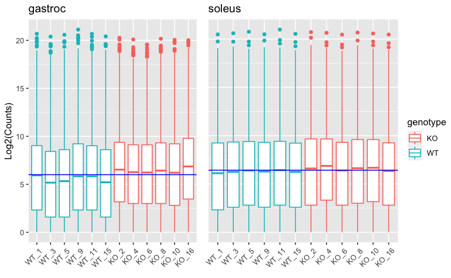

### using DESeq2::rlog to normalize

Just for exploration purpose, but the resulting data is not used in the following analysis.

```r
p1 <- DESeq2::rlog(as.matrix(counts.gastroc)) %>%
  as.data.frame() %>%
  plotBoxLog(metadata.gastroc) +
  ggtitle("gastroc") +
  ylab("rlog(counts)")

p2 <- DESeq2::rlog(as.matrix(counts.soleus)) %>%
  as.data.frame() %>%
  plotBoxLog(metadata.soleus) +
  ggtitle("soleus") +
  theme(axis.ticks.y = element_blank(),
        axis.text.y = element_blank()) +
  rremove("ylab")
```

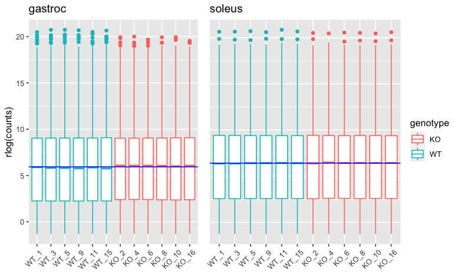

# most variable genes (top 1000) & Normalization

z-score:

$\frac{x - mean(x)}{sd(x)}$

```r
zscore <- function(M) {
  s <- apply( M,1,sd )      # standard deviation
  µ <- apply( M, 1, mean )  # mean
  M.z <- (M - µ) / s        # zscore
  return(M.z)
}

# ' returning the raw counts of the most variable genes by applying zscore and sd
mostVariableRows <- function(M, ntop=1000) {
  M.z <- zscore(M)

  # ordering by sd descending
  sdev <- apply(M.z, 1, sd)
  M.top <- M[order(sdev, decreasing = T)[1:ntop] , ]
  return(M.top)
}

counts.gastroc.top <- mostVariableRows(counts.gastroc)
counts.soleus.top <- mostVariableRows(counts.soleus)
```

## visualization with Heatmaps

### `ComplexHeatmap`

The following Heatmaps are done with `ComplexHeatmap` but are very bad looking.

#### gastroc

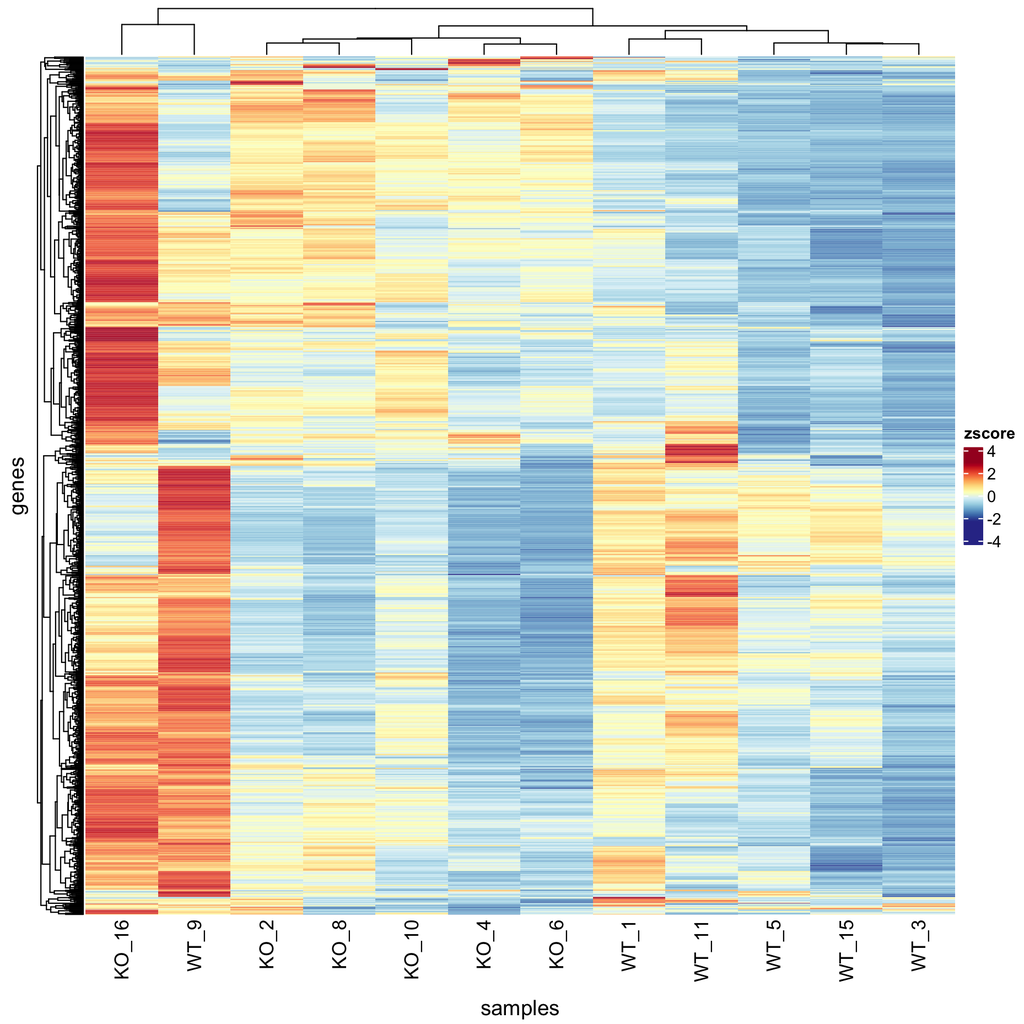

```r
# ' returning a CHM with the z-scored counts
plotCHM <- function(counts) {
  # Get some nicer colours
  mypalette <- brewer.pal(11, "RdYlBu")
  # http://colorbrewer2.org/#type=sequential&scheme=BuGn&n=3
  morecols <- colorRampPalette(mypalette)

  chm <- Heatmap(
    zscore(counts),
    row_title = "genes",
    name = "zscore",
    show_row_names = FALSE,
    column_title = "samples",
    col = rev(morecols(50)),
    column_title_side = "bottom"
  )
  return(chm)
}

plotCHM(counts.gastroc.top)
```

#### soleus

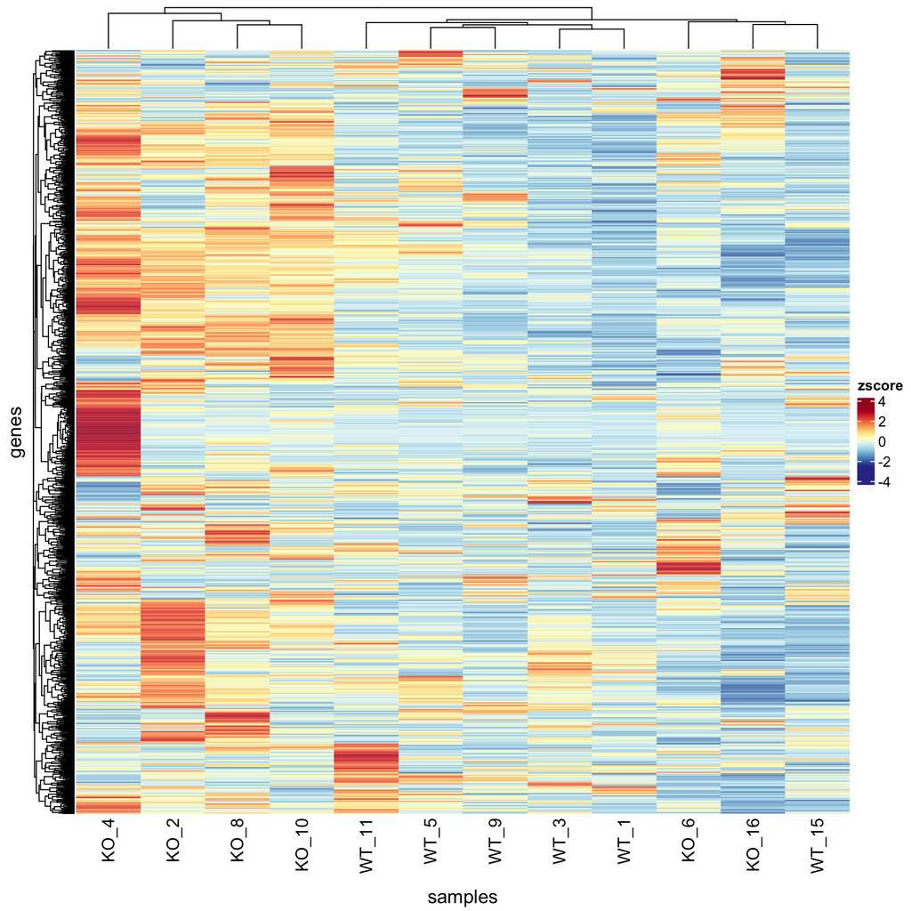

```r
plotCHM(counts.soleus.top)
```

# PCA

## gastroc

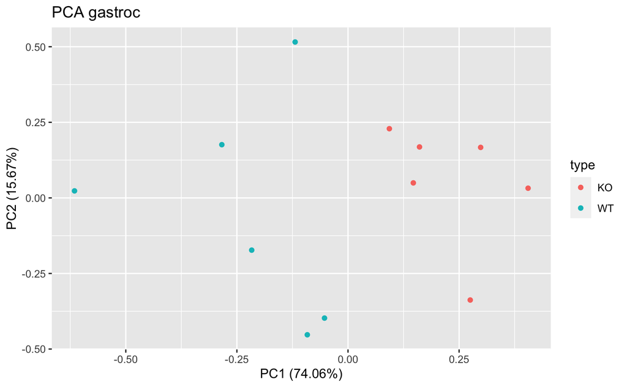

```r
pca <- prcomp(t(counts.gastroc.top), .scale=T)
pca.data <- data.frame(Sample = rownames(pca$x),
                       X = pca$x[, 1],
                       Y = pca$x[, 2]) %>%
  mutate(type = substr(Sample, 1,2))

plt <-
  autoplot(
    pca,
    data = pca.data,
    colour = 'type',
    label.show.legend = FALSE
  ) +
  ggtitle("PCA gastroc")
# ggsave(filename = "./plots/04_pca_gastroc_filtered.png", plt, dpi=300)
plt
```

## soleus

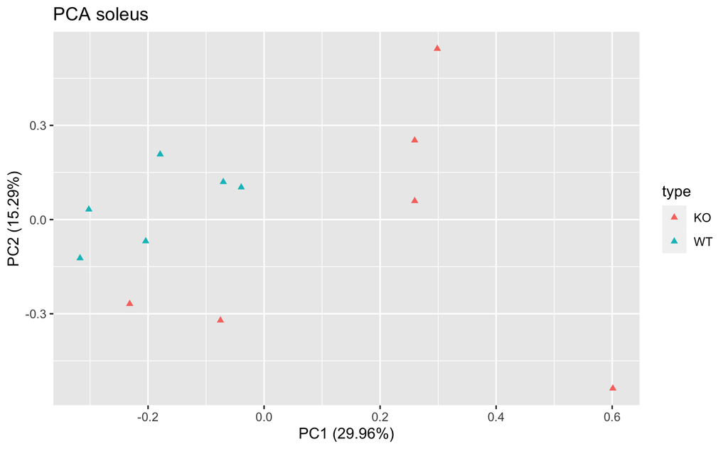

```r
pca <- prcomp(t(counts.soleus.top), scale. = T)

pca.data <- data.frame(Sample = rownames(pca$x),
                       X = pca$x[, 1],
                       Y = pca$x[, 2]) %>%
  mutate(type = substr(Sample, 1,2))

plt <-
  autoplot(
    pca,
    data = pca.data,
    colour = 'type',
    shape = 17,
    label.show.legend = FALSE
  ) +
  ggtitle("PCA soleus")
# ggsave(filename = "./plots/04_pca_soleus_filtered.png", plt, dpi=300)
plt
```

## both tissues

Here also taking the top 1000 most variable genes of each tissue and merging them.

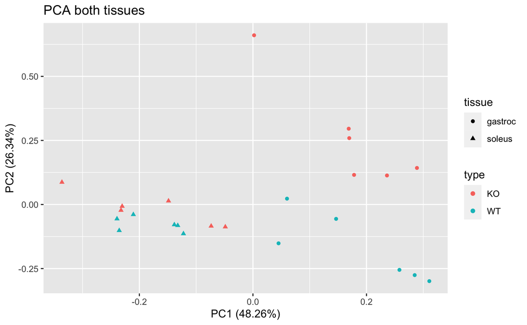

```r
# combine both count tables
counts.both <-
  merge(counts.gastroc.top,
        counts.soleus.top,
        by = 0,
        suffixes = c("_gastroc", "_soleus")) %>%
  tibble::column_to_rownames("Row.names")

pca <- prcomp(t(counts.both), scale. = T)

pca.data <- data.frame(Sample = rownames(pca$x),
                       X = pca$x[, 1],
                       Y = pca$x[, 2]) %>%
  mutate(type = substr(Sample, 1, 2),
         tissue = stringr::str_extract(Sample,"[:alpha:]+$"))

plt <-
  autoplot(
    pca,
    data = pca.data,
    colour = 'type',
    shape = 'tissue',
    label.show.legend = FALSE
  ) +
  ggtitle("PCA both tissues")
# ggsave(filename = "./plots/04_pca_both_tissues_filtered.png", plt, dpi=300)
plt
```

# cleaning up

## SE

```r
# ordering data.frames by rowname
gastroc <- gastroc[order(rownames(gastroc)),]
soleus <- soleus[order(rownames(soleus)),]

# rowData
rowdata.gastroc <- gastroc[, 13:21]
rowdata.soleus <- rowdata.gastroc # should be the same I think
rowdata.gastroc$filtered = rownames(rowdata.gastroc) %in% rownames(counts.gastroc)
rowdata.soleus$filtered  = rownames(rowdata.soleus) %in% rownames(counts.soleus)

se.gastroc <- SummarizedExperiment(
  assays = list(
    "gastroc" = as.matrix(gastroc[, 1:12])
  ),
  rowData = rowdata.gastroc,
  colData = metadata.gastroc[, 3, drop = F] # only genotype is available as information
)

se.soleus <- SummarizedExperiment(
  assays = list(
    "soleus" = as.matrix(soleus[, 1:12])
  ),
  rowData = rowdata.soleus,
  colData = metadata.soleus[, 3, drop = F] # only genotype is available as information
)
```

the filtered assays can be accessed as following:

```r
counts.preFiltered <- se[rowData(se)$filtered,] %>% assay()
```

## save R Objects

```r
saveRDS(se.gastroc,             file = "./data/Robjects/01_se.gastroc.rds")
saveRDS(se.soleus,             file = "./data/Robjects/01_se.soleus.rds")

# (redundant)
saveRDS(counts.gastroc, file = "./data/Robjects/counts.gastroc.rds")
saveRDS(counts.soleus,  file = "./data/Robjects/counts.soleus.rds")
```

# Questions

Most variable genes:

- which heatmap function should I use and what should I change about the plots?
- should I include the traces?
- should I completely omit the heatmaps (visualisation of most variable genes?)